# Introduction to Python coroutines

There is much more to yield!

Noam Elfanbaum  
noamelf.com  
[@noamelf](https://twitter.com/noamelf)

## Introduction

- In 1963 Melvine Conway (not the same guy from the Game of Life) came out with a paradaigm that will allow him to decouple COBOL programs into seperate units ([Design of a Separable Transition-Diagram Compiler](http://www.citemaster.net/get/ab3afb46-1d2a-11e4-ac35-00163e009cc7/p396-conway.pdf)). Instead of a routine that pass control to a subroutine and then gets it back, you have co-routines that passes control simultanoiusly from one another.

> Subroutines are special cases of... coroutines. – [Donald Knuth](http://en.wikipedia.org/wiki/Coroutine#cite_note-KnuthVol1_1_4_2-3)
- Coroutines paradigm was introduced to Python 2.5 in [PEP 342](http://legacy.python.org/dev/peps/pep-0342/) with the motivation of expanding the language expressivness as Guido and Phillip write in the PEP motivation section:

  > Coroutines are a natural way of expressing many algorithms, such as simulations, games, asynchronous I/O, and other forms of event- driven programming or co-operative multitasking.

## Basics

Each componenet is one of the building blocks of the one underneath:

- Iterators
- Generators
- Coroutines

### Iterators

Iterator objects represents a sequence of data. The iterator specification (protocol) includes 2 methods each iterator object must implement:

- `__iter__` - return the object itself.
- `__next__` - returns the next object in the sequence, raises `StopIteration` if empty.

```python
# A class implementing the iterator protocol
class iter_range(object):
    def __init__(self, n):
        self.i = 0
        self.n = n

    def __iter__(self):
        return self

    def  __next__ (self):
        if self.i < self.n:
            i = self.i
            self.i += 1
            return i
        else:
            raise StopIteration()
```

```python
it = iter_range(3)
for i in it:
    print(i, end=' ')
```

```
0 1 2
```

### Generators

Generators helps us generate iterators easily. A generator is essentially a functions that contains a `yield` statement in it's body.

```python
def gen_range(n):
    i = 0
    while i < n:
        yield i
        i += 1
```

```python
it = gen_range(3)
for i in it:
    print(i, end=' ')
```

```
0 1 2
```

### Coroutines

Coroutines are very similar to generators but they utilize the yield statement to consume values.

```python
def grep(pattern):
 print('Looking for {}'.format(pattern))
 while True:
     line = yield
     if pattern in line:
         print(line)
```

```python
g = grep('python')
next(g)
```

```
Looking for python
```

```python
g.send('Yeah, but no, but yeah, but no')
g.send('A series of tubes')
g.send("python coroutines rock!")
```

```
python coroutines rock!
```

#### Coroutine initialization

A coroutine decorater to remove the need for calling `next` each time.

```python
def coroutine(func):
    def start(*args,**kwargs):
        cr = func(*args,**kwargs)
        next(cr)
        return cr
    return start
```

#### `close` and `throw`

- When `close` is called a coroutine, a `GeneratorExit` exception is thrown, and the coroutine will end (the fact the exception is caught doesn't matter, the coroutine will exit anyhow).
- Same goes for `throw`, just that you can decide which exeption will be thrown and you can return a value (see examples).

```python
# close() example
@coroutine
def add_up():
    s = 0
    try:
        while True:
            x = yield
            print(x, end=' ')
            s += x
    except GeneratorExit:
        print('\nThe sum is {}. Cleaning up.'.format(s))
```

```python
adder_gen = add_up()
for i in range(5):
    adder_gen.send(i)
adder_gen.close()
```

```
0 1 2 3 4
The sum is 10. Cleaning up.
```

```python
# throw() example
@coroutine
def throw_me_an_exception():
    try:
        while True:
            x = yield
    except InterruptedError as e:
        print(e)
        yield 'got it'
```

```python
thrower_gen = throw_me_an_exception()
answer = thrower_gen.throw(InterruptedError, 'stop it')
print(answer)

#next(thrower_gen)
```

```
stop it
got it
```

#### Objects vs Coroutines

It seems that there is a great similarity between regular objects and coroutines: they both has data members that can hold states. Then why use coroutines? Let's see [David Beasely's](http://www.dabeaz.com/coroutines/index.html) grep benchmark comparison:

```python
# Benchmark authored by David Beasely - http://www.dabeaz.com/coroutines/index.html

class GrepHandler(object):
    def __init__(self, pattern, target):
        self.pattern = pattern
        self.target = target

    def send(self, line):
        if self.pattern in line:
            self.target.send(line)


@coroutine
def grep(pattern, target):
    while True:
        line = yield
        if pattern in line:
            target.send(line)


# A null-sink to send data
@coroutine
def null():
    while True: item = yield

line = 'python is nice'
p1 = grep('python', null())  # Coroutine
p2 = GrepHandler('python', null())  # Object

%timeit -n 1000 p1.send(line)
%timeit -n 1000 p2.send(line)
```

```
1000 loops, best of 3: 423 ns per loop
1000 loops, best of 3: 465 ns per loop
```

**So by using coroutines we get:**

- Elegance (agruable).
- Speed.
- Job security (only you understand the code :) )

## Use cases

As [PEP 342](http://legacy.python.org/dev/peps/pep-0342/) mentions and Knuth & Ruskey decribes thouroughly in [Deconstructing Coroutines](http://citeseerx.ist.psu.edu/viewdoc/download;jsessionid=98EAC35E08B1DB945E499F455F6EAD1E?doi=10.1.1.19.79&rep=rep1&type=pdf), coroutines can supply an elegant solution to a varaity of problems, in fact Python's asycio package is based on them being called by an event loop (but that's for another talk).

### Use case 1 - Pipes

- Pipes allows us to proccess large amounts of data without worrying about memory footprint and following unexpected crushes.
- Since we each chunk of data finishes the cycle as it is read, even if some mischief happens, the proccess does not need restart from the top.
- Using coroutines we can create pipes that are produced from small and modular units (hence unittests friendly).

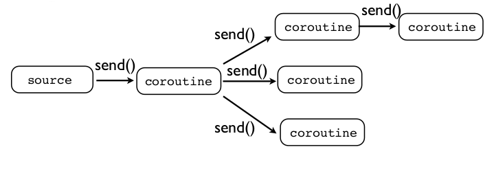

```python
# An illustration of coroutines 'branching' ability.

from IPython.display import Image,display_png
display_png(Image('images/branchy.png'))
```

```python
# A sink.  A coroutine that receives data
@coroutine
def printer():
    while True:
         line = yield
         print(line)

# A filter.
@coroutine
def grep(pattern,target):
    while True:
        line = yield
        if pattern in line:
            target.send(line)

# Broadcast a stream onto multiple targets
@coroutine
def broadcast(*targets):
    while True:
        item = yield
        for target in targets:
            target.send(item)

def producer(broadcast):
    with open('log') as f:
        for line in f:
            broadcaster.send(line)

if __name__ == '__main__':
    p = printer()
    producer(broadcast(grep('startup',p), grep('font',p), grep('libjs',p)))
```

```
2015-05-01 11:13:38 startup archives unpack

2015-05-01 11:13:45 install fonts-font-awesome:all <none> 4.2.0~dfsg-1

2015-05-01 11:13:45 status half-installed fonts-font-awesome:all 4.2.0~dfsg-1

2015-05-01 11:13:45 status triggers-pending fontconfig:amd64 2.11.1-0ubuntu6

2015-05-01 11:13:46 status unpacked fonts-font-awesome:all 4.2.0~dfsg-1

2015-05-01 11:13:46 status unpacked fonts-font-awesome:all 4.2.0~dfsg-1

2015-05-01 11:13:46 install fonts-mathjax:all <none> 2.5.1-1

2015-05-01 11:13:46 status half-installed fonts-mathjax:all 2.5.1-1

2015-05-01 11:13:46 status unpacked fonts-mathjax:all 2.5.1-1

2015-05-01 11:13:46 status unpacked fonts-mathjax:all 2.5.1-1

2015-05-01 11:13:47 install libjs-highlight.js:all <none> 8.2+ds-4

2015-05-01 11:13:47 status half-installed libjs-highlight.js:all 8.2+ds-4

2015-05-01 11:13:47 status unpacked libjs-highlight.js:all 8.2+ds-4

2015-05-01 11:13:47 status unpacked libjs-highlight.js:all 8.2+ds-4

2015-05-01 11:13:47 install libjs-highlight:all <none> 8.2+ds-4

2015-05-01 11:13:47 status half-installed libjs-highlight:all 8.2+ds-4

2015-05-01 11:13:48 status unpacked libjs-highlight:all 8.2+ds-4

2015-05-01 11:13:48 status unpacked libjs-highlight:all 8.2+ds-4

2015-05-01 11:13:48 install libjs-jquery:all <none> 1.7.2+dfsg-3ubuntu2

2015-05-01 11:13:48 status half-installed libjs-jquery:all 1.7.2+dfsg-3ubuntu2

```

[output cut: 122 more lines]

```
2015-05-04 11:58:33 startup packages configure

2015-05-04 13:30:49 startup archives unpack

2015-05-04 13:31:05 startup packages configure

2015-05-04 13:31:09 startup packages configure

2015-05-04 14:36:24 startup archives unpack

2015-05-04 14:36:52 startup packages configure

2015-05-04 14:37:06 startup packages configure

2015-05-04 14:37:07 startup archives install
```

### Pipes example #2

In this example, we need fetch data from furniture.com. As with any pipe we can abstract the steps taken to 3:

1. **Producer** - API request to furniture.com.
2. **Filter** - filtering and formating the data to match our needs.
3. **Sink/Consumers** - Update our DB and indexer.